# 1. Define the problem and perform an Exploratory Data Analysis

### Problem Statements:

AllLife Bank wants to focus on its credit card customer base in the next financial year. They have been advised by their marketing research team, that the penetration in the market can be improved. Based on this input, the Marketing team proposes to run personalised campaigns to target new customers as well as upsell to existing customers. Another insight from the market research was that the customers perceive the support services of the back poorly. Based on this, the Operations team wants to upgrade the service delivery model, to ensure that customers queries are resolved faster. Head of Marketing and Head of Delivery both decide to reach out to the Data Science team for help

### Objective:

To identify different segments in the existing customer based on their spending patterns as well as past interaction with the bank.

### 1.1 Import Libraries

```python
# Library to suppress warnings or deprecation notes
import warnings
warnings.filterwarnings('ignore')

# Libraries to help with reading and manipulating data
import numpy as np
import pandas as pd

# Libraries to help with data visualization
import matplotlib.pyplot as plt
%matplotlib inline
import seaborn as sns
import scipy.stats as stats

# Libraries to split data, impute missing values
from sklearn.model_selection import train_test_split, StratifiedKFold, cross_val_score
from sklearn.impute import SimpleImputer

# Library for preprocessing
from sklearn.preprocessing import StandardScaler

#### generate the linkage matrix, dentogram and cluster
from scipy.cluster.hierarchy import dendrogram, linkage, cophenet
from scipy.cluster.hierarchy import fcluster
from sklearn.cluster import AgglomerativeClustering
from scipy.spatial.distance import cdist
from scipy.spatial.distance import pdist

# Libraries for KMeans Cluster
from sklearn.cluster import KMeans
from yellowbrick.cluster import KElbowVisualizer, SilhouetteVisualizer

# Calculate Avg Silhoutte Score
from sklearn.metrics import silhouette_score
from scipy.stats import zscore

# Library to build a logistic regression model, Randonm Forest, AdaBoost
from sklearn.linear_model import LogisticRegression
from sklearn.ensemble import RandomForestClassifier
from sklearn.ensemble import AdaBoostClassifier
```

```python
# To read the Credit Card Customer Data.xlsx file having sheet name -Sheet1 into dataframe
CC_df = pd.read_excel("Credit Card Customer Data.xlsx",sheet_name="Sheet1")
CC_copy = CC_df.copy() # To backup the file

CC_df.head(10)
```

|  | Sl_No | Customer Key | Avg_Credit_Limit | Total_Credit_Cards | Total_visits_bank | Total_visits_online | Total_calls_made |
| --- | --- | --- | --- | --- | --- | --- | --- |
| 0 | 1 | 87073 | 100000 | 2 | 1 | 1 | 0 |
| 1 | 2 | 38414 | 50000 | 3 | 0 | 10 | 9 |
| 2 | 3 | 17341 | 50000 | 7 | 1 | 3 | 4 |
| 3 | 4 | 40496 | 30000 | 5 | 1 | 1 | 4 |
| 4 | 5 | 47437 | 100000 | 6 | 0 | 12 | 3 |
| 5 | 6 | 58634 | 20000 | 3 | 0 | 1 | 8 |
| 6 | 7 | 48370 | 100000 | 5 | 0 | 11 | 2 |
| 7 | 8 | 37376 | 15000 | 3 | 0 | 1 | 1 |
| 8 | 9 | 82490 | 5000 | 2 | 0 | 2 | 2 |
| 9 | 10 | 44770 | 3000 | 4 | 0 | 1 | 7 |

### 1.2 Observations on Data

```python
#Shape of the data (rows and columns)
print('There are :', CC_df.shape[0] ,'rows and', CC_df.shape[1], 'columns')
```

```
There are : 660 rows and 7 columns
```

```python
#dropping the serial no. column as it does not hold any statistical significance
CC_df.drop('Sl_No',axis=1,inplace=True)
CC_df.drop('Customer Key',axis=1,inplace=True)
```

```python
#To view dataframe details
CC_df.info()
```

```
<class 'pandas.core.frame.DataFrame'>
RangeIndex: 660 entries, 0 to 659
Data columns (total 5 columns):
 #   Column               Non-Null Count  Dtype
---  ------               --------------  -----
 0   Avg_Credit_Limit     660 non-null    int64
 1   Total_Credit_Cards   660 non-null    int64
 2   Total_visits_bank    660 non-null    int64
 3   Total_visits_online  660 non-null    int64
 4   Total_calls_made     660 non-null    int64
dtypes: int64(5)
memory usage: 25.9 KB
```

- All the features provided are integer datatypes
- There is no null values in any of the features

```python
CC_df.describe().T
```

|  | count | mean | std | min | 25% | 50% | 75% | max |
| --- | --- | --- | --- | --- | --- | --- | --- | --- |
| Avg_Credit_Limit | 660.0 | 34574.242424 | 37625.487804 | 3000.0 | 10000.0 | 18000.0 | 48000.0 | 200000.0 |
| Total_Credit_Cards | 660.0 | 4.706061 | 2.167835 | 1.0 | 3.0 | 5.0 | 6.0 | 10.0 |
| Total_visits_bank | 660.0 | 2.403030 | 1.631813 | 0.0 | 1.0 | 2.0 | 4.0 | 5.0 |
| Total_visits_online | 660.0 | 2.606061 | 2.935724 | 0.0 | 1.0 | 2.0 | 4.0 | 15.0 |
| Total_calls_made | 660.0 | 3.583333 | 2.865317 | 0.0 | 1.0 | 3.0 | 5.0 | 10.0 |

- The Average credit card limit is between minimum 3000 to max 200000. The data provided is right skewed and has some outliers.
- Total credit cards is between minimum 1 and maximum 10 cards. The data looks slightly left skewed.
- Total visits bank is between minimum 0 and maximum 5 visits. The data looks slight right skewed.
- Total visits online is between minimum 0 and maximum 15 visits. The data looks slight right skewed and with some outliers.
- Total calls made is between minimum 0 and maximum 10. The data looks slightly right skewed.

```python
CC_df.dtypes
```

```
Avg_Credit_Limit       int64
Total_Credit_Cards     int64
Total_visits_bank      int64
Total_visits_online    int64
Total_calls_made       int64
dtype: object
```

```python
#To check for the missing values
CC_df.isna().sum()
```

```
Avg_Credit_Limit       0
Total_Credit_Cards     0
Total_visits_bank      0
Total_visits_online    0
Total_calls_made       0
dtype: int64
```

- There is no null values

### 1.4 Univariate Analysis

Before we process data, lets take the graphical visualization of the data to understand better.

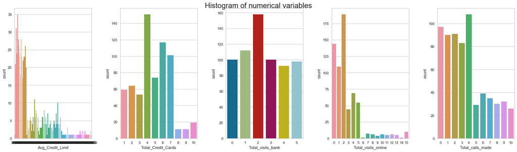

```python
all_col = CC_df.iloc[:,:].columns.tolist()
fig, axes = plt.subplots(1, 5,  figsize=(20, 6))
fig.suptitle('Histogram of numerical variables', fontsize=20)
counter = 0
for ii in range(5):
    sns.countplot(ax=axes[ii],x=CC_df[all_col[counter]])
    counter = counter+1

fig.tight_layout(pad=2.0)
```

**Observations**

- Most of customers have average credit limit with lower amounts. The graph shows above the count of 20 is for lower credit limits.
- Most of customers have 4 credit cards and a least customers have 8 or 9 credit cards
- Most of customers visit banks for 2 days and least customers visit 4 days
- Most of customers visit online 2 times and least customers visit 6 or 14 times.
- Most of customers make 4 calls and least customers make 10 calls.

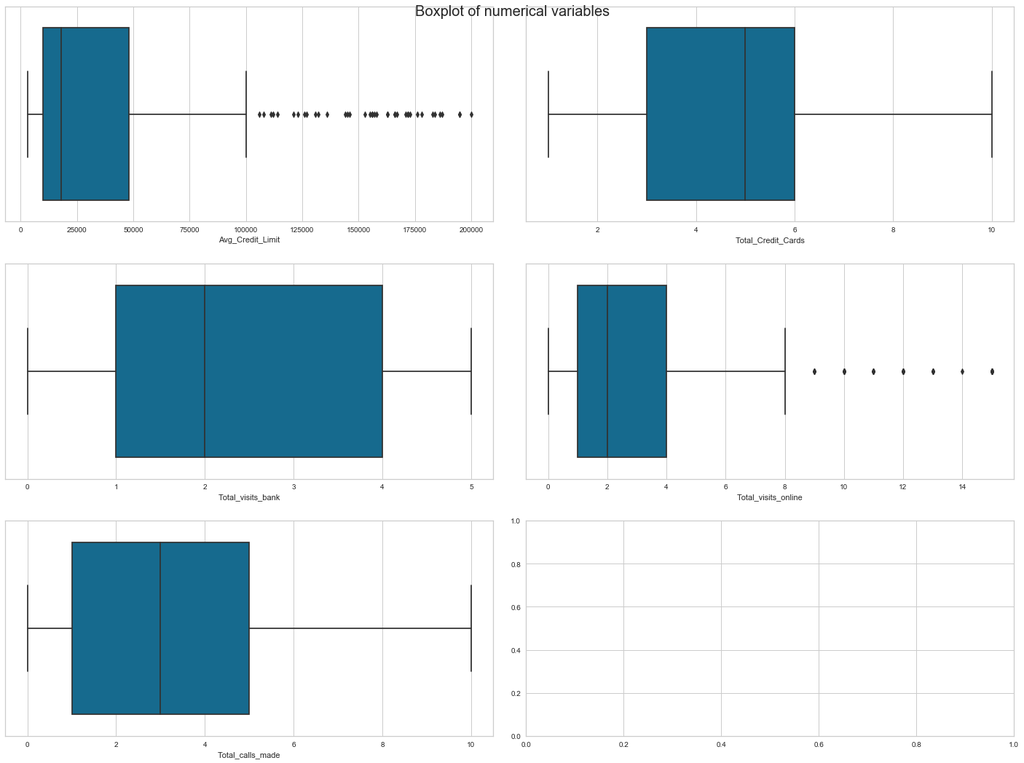

```python
# selecting numerical columns
all_col = CC_df.select_dtypes(include=np.number).columns.tolist()

fig, axes = plt.subplots(3, 2,  figsize=(20, 15))
fig.suptitle('Boxplot of numerical variables', fontsize=20)
counter = 0
for ii in range(3):
    sns.boxplot(ax=axes[ii][0],x=CC_df[all_col[counter]])
    counter = counter+1
    if counter != 5:
        sns.boxplot(ax=axes[ii][1],x=CC_df[all_col[counter]])
        counter = counter+1
    else:
        pass

fig.tight_layout(pad=2.0)
```

**Observations**

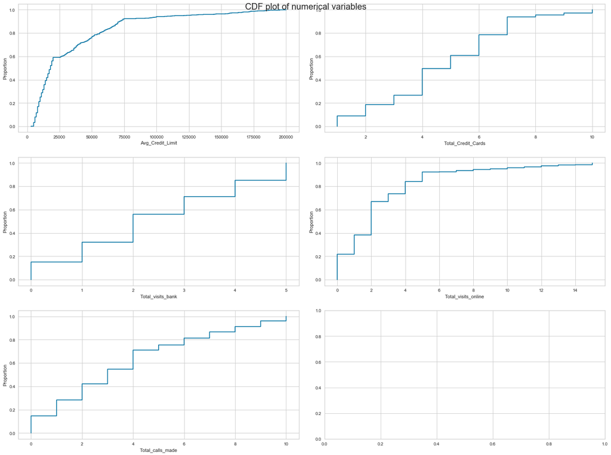

```python
# select numerical columns
all_col = CC_df.select_dtypes(include=np.number).columns.tolist()

fig, axes = plt.subplots(3, 2,  figsize=(20, 15))
fig.suptitle('CDF plot of numerical variables', fontsize=20)
counter = 0
for ii in range(3):
    sns.ecdfplot(ax=axes[ii][0],x=CC_df[all_col[counter]])
    counter = counter+1
    if counter != 5:
        sns.ecdfplot(ax=axes[ii][1],x=CC_df[all_col[counter]])
        counter = counter+1
    else:
        pass

fig.tight_layout(pad=2.0)
```

**Observations**

### Bivariate Analysis

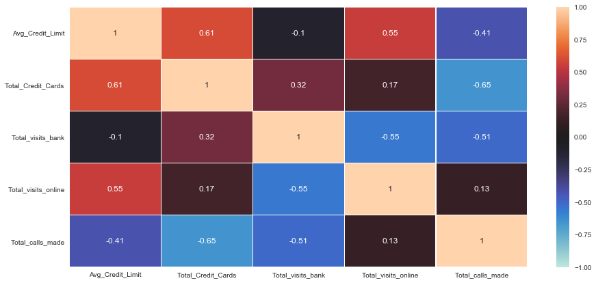

```python
plt.figure(figsize=(15,7))

sns.heatmap(CC_df[all_col].corr(),
            annot=True,
            linewidths=0.5,vmin=-1,vmax=1,
            center=0,
            cbar=True,)

plt.show()
```

**Observations**

- Total credit card and Average credit limit are strongly positive correlated (0.61). As number of credit card increases average credit limit also increases.
- Average credit limit and Total visits online are strongly positive correlated (0.55).
- Total credit cards and Total visit banks are slightly positive correlated(0.32).

There are some negative correlations below,

- As Average credit limit increases,the Total calls made reduced and vice versa.
- As Total credit cards increases, the Total calls made reduced and vice versa.
- As Total visits bank increases, the Total calls made reduced and vice versa.
- As Total visits online increases, the Total visits bank reduced and vice versa.

# 2.Illustrate the insights based on EDA

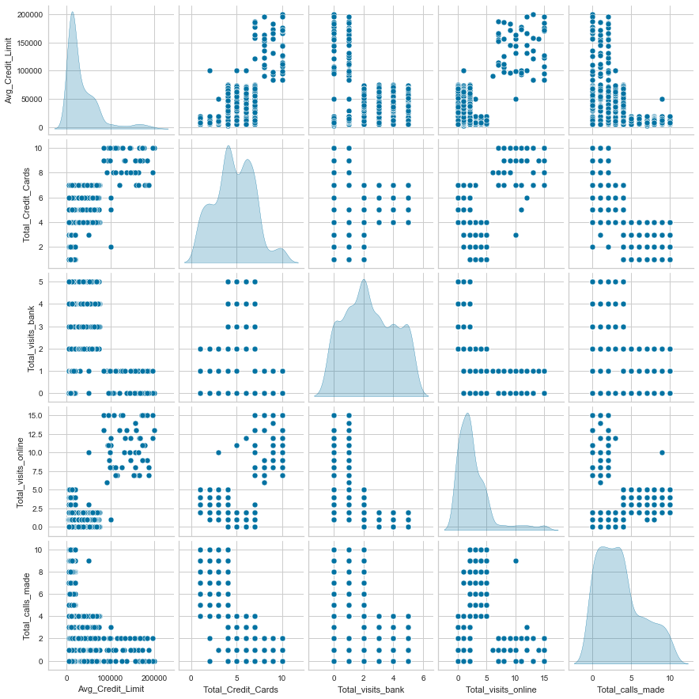

```python
sns.pairplot(CC_df[all_col],diag_kind="kde")
```

**Observations**

- Average credit limit is not uniformly distributed with right skewed.
- Average credit limit increases as total credit cards increases.
- Average credit limit decreases as total visits bank increases.
- Average credit limit decreases as total calls made increases.
- Total credit cards seems to have 4 models
- Total credit cards decreases as total calls made increases.
- Total visit banks has many models.
- Total visit banks reduces as online visits increases.
- Total visit online is mostly bimodal.
- Total visit online decreases as banks visit increases.
- Total visit online increases as credit limit increases.
- Total calls made seems to be trimodal.
- Total calls made decreases as other feature count increases.

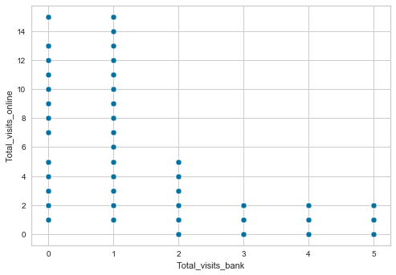

```python
sns.scatterplot(x=CC_df.Total_visits_bank,y=CC_df.Total_visits_online)
```

- The Total online visit reduced drastically to 5 when total bank visit is more than 1.

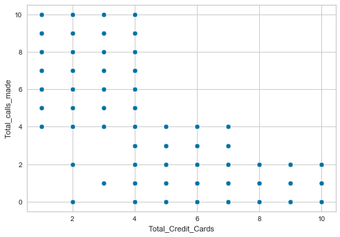

```python
sns.scatterplot(x=CC_df.Total_Credit_Cards,y=CC_df.Total_calls_made)
```

- The total calls made drastically reduced to 4 when total credit card count is more than 4.

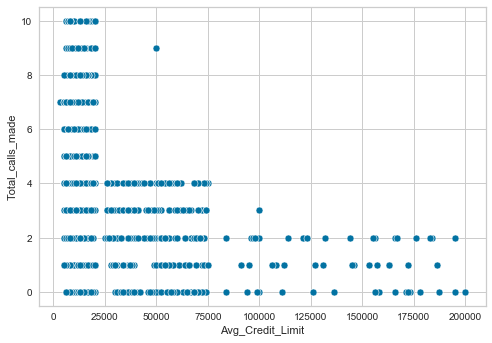

```python
sns.scatterplot(x=CC_df.Avg_Credit_Limit,y=CC_df.Total_calls_made)
```

- The total calls reduced to 4 when average credit card limit is 25000 and above.

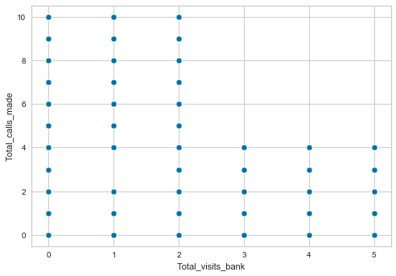

```python
sns.scatterplot(x=CC_df.Total_visits_bank,y=CC_df.Total_calls_made)
```

- The total calls made reduced to 4 when bank visit count is 3 or more

# 3.Data pre-processing

### 3.1 To check for missing values

```python
#To check for any customer record with no visits to bank and online.
CC1_df = CC_df[(CC_df['Total_visits_bank'] == 0) & (CC_df['Total_visits_online'] == 0)]
CC1_df
```

|  | Avg_Credit_Limit | Total_Credit_Cards | Total_visits_bank | Total_visits_online | Total_calls_made |
| --- | --- | --- | --- | --- | --- |

- There is no missing values. i.e There is no customer records with no bank visits and no online visits.

### 3.2 Duplicate observations check

```python
#To check for any duplicates in the records
CC_df.duplicated().sum()
```

```
11
```

```python
#To drop any duplicates in the records
CC_df = CC_df[(~CC_df.duplicated())].copy()
```

```python
#To check if duplicates are removed
CC_df.duplicated().sum()
```

```
0
```

### 3.3 Outliers in every numerical column

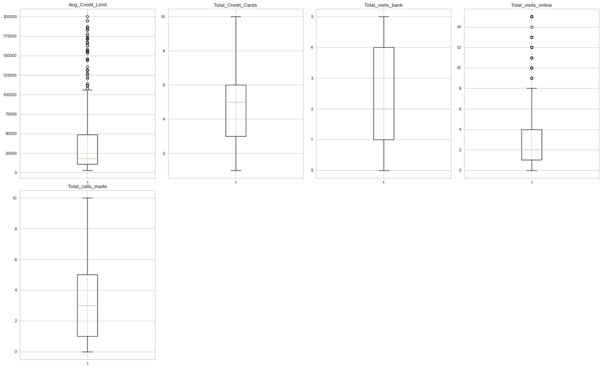

```python
# outlier detection using boxplot
numeric_columns = CC_df.select_dtypes(include=np.number).columns.tolist()
plt.figure(figsize=(20,30))

for i, variable in enumerate(numeric_columns):
                     plt.subplot(5,4,i+1)
                     plt.boxplot(CC_df[variable],whis=1.5)
                     plt.tight_layout()
                     plt.title(variable)

plt.show()
```

- Average credit limit and Total visits online features are having outliers.

### 3.4 Outliers treatment.

```python
# Lets treat outliers by flooring and capping
def treat_outliers(CC_df,col):
    '''
    treats outliers in a varaible
    col: str, name of the numerical varaible
    df: data frame
    col: name of the column
    '''
    Q1=CC_df[col].quantile(0.25) # 25th quantile
    Q3=CC_df[col].quantile(0.75)  # 75th quantile
    IQR=Q3-Q1
    Lower_Whisker = Q1 - 1.5*IQR
    Upper_Whisker = Q3 + 1.5*IQR
    CC_df[col] = np.clip(CC_df[col], Lower_Whisker, Upper_Whisker) # all the values samller than Lower_Whisker will be assigned value of Lower_whisker
                                                            # and all the values above upper_whishker will be assigned value of upper_Whisker
    return CC_df

def treat_outliers_all(CC_df, col_list):
    '''
    treat outlier in all numerical varaibles
    col_list: list of numerical varaibles
    df: data frame
    '''
    for c in col_list:
        CC_df = treat_outliers(CC_df,c)

    return CC_df
```

```python
#Treating the outiers
numerical_col = CC_df.select_dtypes(include=np.number).columns.tolist()
CC_df = treat_outliers_all(CC_df,numerical_col)
```

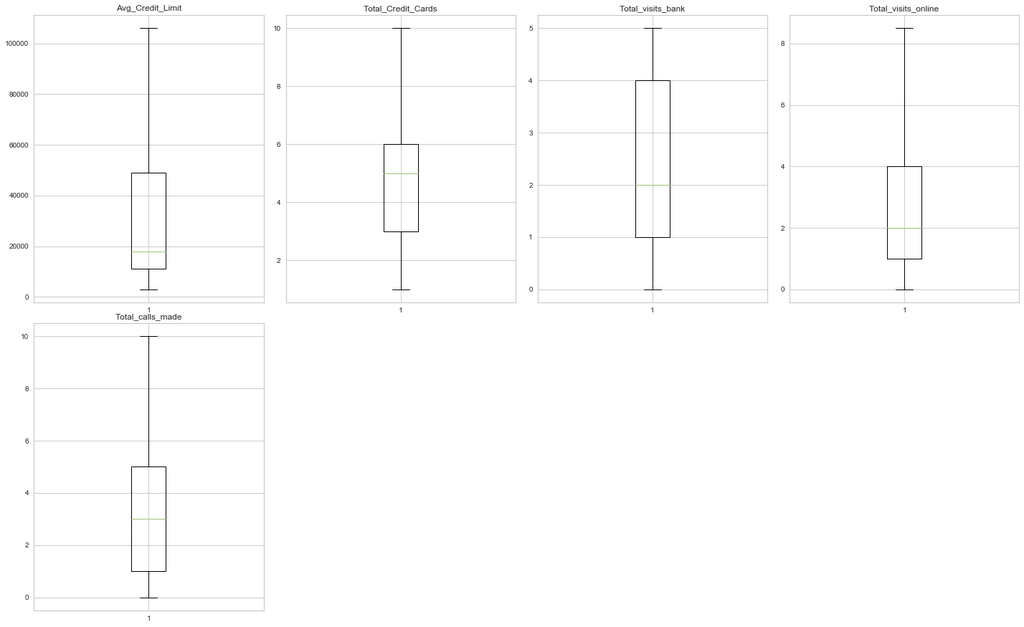

```python
# lets look at box plot to see if outliers has been treated or not
plt.figure(figsize=(20,30))

for i, variable in enumerate(numeric_columns):
                     plt.subplot(5,4,i+1)
                     plt.boxplot(CC_df[variable],whis=1.5)
                     plt.tight_layout()
                     plt.title(variable)

plt.show()
```

**Outliers have been treated**

# 4.Applying K-means clustering algorithms

```python
# Backup of data
CC1_df = CC_df.copy()
```

```python
# Scaling the data set before clustering
scaler=StandardScaler()
subset=CC_df[all_col].copy()
subset_scaled=scaler.fit_transform(subset)
```

```python
#Creating a dataframe from the scaled data above
subset_scaled_df=pd.DataFrame(subset_scaled,columns=subset.columns)
```

```
Number of Clusters: 1 	Average Distortion: 2.073136602035325
Number of Clusters: 2 	Average Distortion: 1.4978375339862937
Number of Clusters: 3 	Average Distortion: 1.1772224293618558
Number of Clusters: 4 	Average Distortion: 1.0689466335012168
Number of Clusters: 5 	Average Distortion: 1.0016955129065774
Number of Clusters: 6 	Average Distortion: 0.9489097302225579
Number of Clusters: 7 	Average Distortion: 0.9122934207446814
Number of Clusters: 8 	Average Distortion: 0.8877702656288248
```

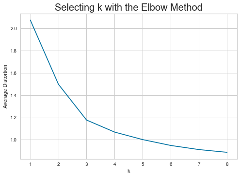

```python
clusters=range(1,9)
meanDistortions=[]

for k in clusters:
    model=KMeans(n_clusters=k)
    model.fit(subset_scaled_df)
    prediction=model.predict(subset_scaled_df)
    distortion=sum(np.min(cdist(subset_scaled_df, model.cluster_centers_, 'euclidean'), axis=1)) / subset_scaled_df.shape[0]

    meanDistortions.append(distortion)

    print('Number of Clusters:', k, '\tAverage Distortion:', distortion)

plt.plot(clusters, meanDistortions, 'bx-')
plt.xlabel('k')
plt.ylabel('Average Distortion')
plt.title('Selecting k with the Elbow Method', fontsize=20)
```

```python
sil_score = []
cluster_list = list(range(2,10))
for n_clusters in cluster_list:
    clusterer = KMeans(n_clusters=n_clusters)
    preds = clusterer.fit_predict((subset_scaled_df))
    #centers = clusterer.cluster_centers_
    score = silhouette_score(subset_scaled_df, preds)
    sil_score.append(score)
    print("For n_clusters = {}, silhouette score is {})".format(n_clusters, score))
```

```
For n_clusters = 2, silhouette score is 0.41999597804777794)
For n_clusters = 3, silhouette score is 0.5180797381243987)
For n_clusters = 4, silhouette score is 0.3803310175027709)
For n_clusters = 5, silhouette score is 0.3547325270386784)
For n_clusters = 6, silhouette score is 0.27181707342998523)
For n_clusters = 7, silhouette score is 0.26731507315697395)
For n_clusters = 8, silhouette score is 0.2564208920421177)
For n_clusters = 9, silhouette score is 0.24380670378562408)
```

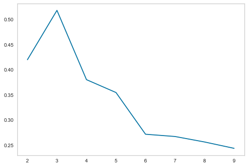

```python
plt.plot(cluster_list,sil_score)
plt.grid()
```

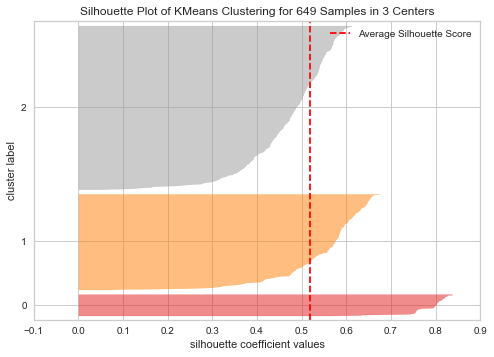

```python
#Finding optimal no. of clusters with silhouette coefficients
visualizer = SilhouetteVisualizer(KMeans(3, random_state = 1))
visualizer.fit(subset_scaled_df)
visualizer.show()
```

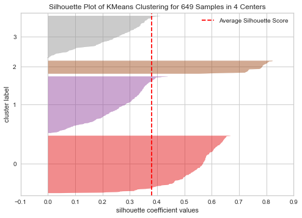

```python
#Finding optimal no. of clusters with silhouette coefficients
visualizer = SilhouetteVisualizer(KMeans(4, random_state = 1))
visualizer.fit(subset_scaled_df)
visualizer.show()
```

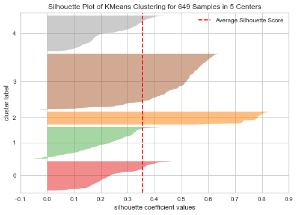

```python
#Finding optimal no. of clusters with silhouette coefficients
visualizer = SilhouetteVisualizer(KMeans(5, random_state = 1))
visualizer.fit(subset_scaled_df)
visualizer.show()
```

### Let us take 3 as appropriate no. of clusters as silhoutte score is high enough and there is knick at 3 in elbow curve.

```python
kmeans = KMeans(n_clusters=3, random_state=0)
kmeans.fit(subset_scaled_df)
```

```
KMeans(n_clusters=3, random_state=0)
```

```python
CC_df['K_means_segments'] = kmeans.labels_
subset_scaled_df['K_means_segments'] = kmeans.labels_
```

```python
cluster_profile = CC_df.groupby('K_means_segments').mean()
```

```python
cluster_profile['count_in_each_segment'] = CC_df.groupby('K_means_segments')['Total_calls_made'].count().values
```

```python
# lets display cluster profile
cluster_profile.style.highlight_max(color = 'lightgreen', axis = 0)
```

| K_means_segments | Avg_Credit_Limit | Total_Credit_Cards | Total_visits_bank | Total_visits_online | Total_calls_made | count_in_each_segment |
| --- | --- | --- | --- | --- | --- | --- |
| 0 | 12239.819005 | 2.411765 | 0.945701 | 3.554299 | 6.891403 | 221 |
| 1 | 34071.428571 | 5.518519 | 3.484127 | 0.981481 | 1.992063 | 378 |
| 2 | 103440.000000 | 8.740000 | 0.600000 | 8.180000 | 1.080000 | 50 |

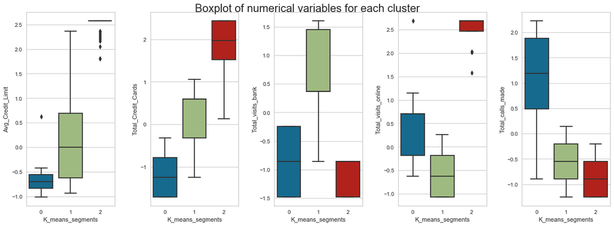

```python
fig, axes = plt.subplots(1, 5,  figsize=(16, 6))
fig.suptitle('Boxplot of numerical variables for each cluster', fontsize=20)
counter = 0
for ii in range(5):
    sns.boxplot(ax=axes[ii],y=subset_scaled_df[all_col[counter]],x=subset_scaled_df['K_means_segments'])
    counter = counter+1

fig.tight_layout(pad=2.0)
```

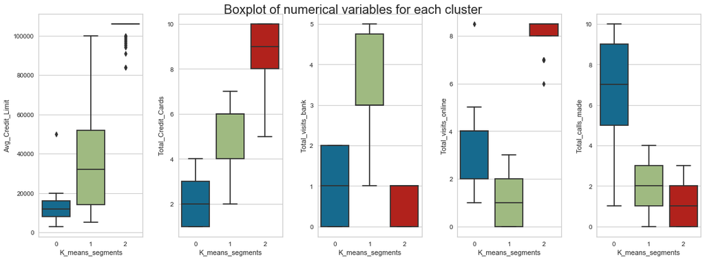

```python
fig, axes = plt.subplots(1, 5,  figsize=(16, 6))
fig.suptitle('Boxplot of numerical variables for each cluster', fontsize=20)
counter = 0
for ii in range(5):
    sns.boxplot(ax=axes[ii],y=CC_df[all_col[counter]],x=CC_df['K_means_segments'])
    counter = counter+1

fig.tight_layout(pad=2.0)
```

*Observations*

- The 3 clusters are created for the Customer data.
- Average Credit limit in 3 clusters are: limit below 20000, limit between 15000 and 50000, limit beyond 80000.
- Total credit cards in 3 clusters: below 4, 4 to 6 cards and 8 to 10 cards segments
- Total visits banks in 3 clusters: 0 to 1, 0 to 2, 3 to 5 visits
- Total visits online in 3 clusters: 0 to 2, 2 to 4, 8 to 9 visits
- Total calls made in 3 clusters: 0 to 2, 1 to 3, 5 to 9 calls made.

# 5.Applying Hierarchical clustering

```python
# variables used for clustering
all_col
```

```
['Avg_Credit_Limit',
 'Total_Credit_Cards',
 'Total_visits_bank',
 'Total_visits_online',
 'Total_calls_made']
```

```python
# Scaling the dataset before clustering
scaler=StandardScaler()
subset=CC1_df[all_col].copy()
subset_scaled = scaler.fit_transform(subset)
```

```python
# Creating a dataframe of the above results
subset_scaled_df = pd.DataFrame(subset_scaled,columns=subset.columns)
```

```python
# cophenet index is a measure of the correlation between the distance of points in feature space and distance on dendrogram
# closer it is to 1, the better is the clustering
distance_metrics = [ 'euclidean','chebyshev','mahalanobis','cityblock']
linkage_methods = ['single', 'complete', 'average', 'weighted']
high_cophenet_corr = 0
high_dm_lm = [0,0]
for dm in distance_metrics:
    for lm in linkage_methods:
        Z = linkage(subset_scaled_df, metric=dm, method=lm)
        c, coph_dists = cophenet(Z , pdist(subset_scaled_df))
        print('Cophent correlation for distance metrics {} and linkahe method {} is {}'.format(dm,lm,c))
        if high_cophenet_corr < c:
            high_cophenet_corr = c
            high_dm_lm[0] = dm
            high_dm_lm[1] = lm
```

```
Cophent correlation for distance metrics euclidean and linkahe method single is 0.6687980551717484
Cophent correlation for distance metrics euclidean and linkahe method complete is 0.8455463448314544
Cophent correlation for distance metrics euclidean and linkahe method average is 0.8922750152191901
Cophent correlation for distance metrics euclidean and linkahe method weighted is 0.8874605817813397
Cophent correlation for distance metrics chebyshev and linkahe method single is 0.6904171632443976
Cophent correlation for distance metrics chebyshev and linkahe method complete is 0.8256908105714492
Cophent correlation for distance metrics chebyshev and linkahe method average is 0.8890063310233792
Cophent correlation for distance metrics chebyshev and linkahe method weighted is 0.8820500156009561
Cophent correlation for distance metrics mahalanobis and linkahe method single is 0.659249865882007
Cophent correlation for distance metrics mahalanobis and linkahe method complete is 0.4243540966152355
Cophent correlation for distance metrics mahalanobis and linkahe method average is 0.7988622717266837
Cophent correlation for distance metrics mahalanobis and linkahe method weighted is 0.6423539449312023
Cophent correlation for distance metrics cityblock and linkahe method single is 0.6718341146221024
Cophent correlation for distance metrics cityblock and linkahe method complete is 0.8328113244932631
Cophent correlation for distance metrics cityblock and linkahe method average is 0.8914496698322413
Cophent correlation for distance metrics cityblock and linkahe method weighted is 0.8559905391810056
```

```python
print('Highest cophenet correlation is {}, which is obtinaed with {} distance metric and {} linkage method'.format(high_cophenet_corr ,high_dm_lm[0],high_dm_lm[1]))
```

```
Highest cophenet correlation is 0.8922750152191901, which is obtinaed with euclidean distance metric and average linkage method
```

### Lets explore 'centroid', 'median','ward' linkage method which requires only Euclidean distance metrics

```python
linkage_methods = ['single', 'complete', 'average','median','ward', 'weighted']
high_cophenet_corr = 0
high_dm_lm = [0,0]

for lm in linkage_methods:
    Z = linkage(subset_scaled_df, metric='euclidean', method=lm)
    c, coph_dists = cophenet(Z , pdist(subset_scaled_df))
    print('Cophent correlation for distance metrics {} and linkage method {} is {}'.format('euclidean',lm,c))
    if high_cophenet_corr < c:
        high_cophenet_corr = c
        high_dm_lm[0] = dm
        high_dm_lm[1] = lm
print('*'*110)
print('Highest cophenet correlation is {}, which is obtained with {} distance metric and {} linkage method'.format(high_cophenet_corr ,high_dm_lm[0],high_dm_lm[1]))
```

[output not shown]

**Observations**

- we see that cophenet index is maximum with euclidean distance metric and average linkage method.
- Lets see the dendrogram of different linkage method

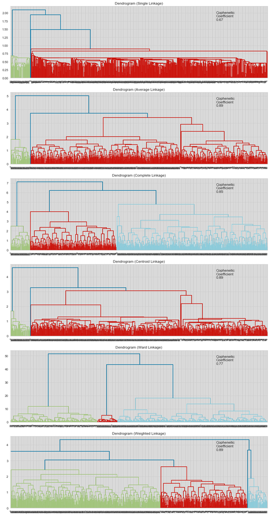

```python
# List of all linkage methods to check
methods = ['single',
           'average',
           'complete',
           'centroid',
           'ward',
           'weighted']

# Calculate the pairwise distance form the dataset to be used in the cophenetic correlation calculation
#pw_distance = pdist(credit_scaled)

# Create lists to save results of coph calculation
compare_cols = ['Linkage', 'Cophenetic Coefficient']
compare = []

# Create a subplot image
fig, axs = plt.subplots(len(methods), 1, figsize=(15, 30))

# Enumerate through the list of all methods above
# Get linkage, plot dendrogram, calculate cophenetic coefficient
for i, method in enumerate(methods):

    Z = linkage(subset_scaled_df, metric='euclidean', method=method)

    dendrogram(Z, ax=axs[i]);
    axs[i].set_title(f'Dendrogram ({method.capitalize()} Linkage)')
    coph_corr, coph_dist = cophenet(Z, pdist(subset_scaled_df))
    axs[i].annotate(f'Cophenetic\nCoefficient\n{coph_corr:0.2f}',
                    (0.80, 0.80),
                    xycoords='axes fraction')
    compare.append([method, coph_corr])
```

```python
# Create and print dataframe to compare Cophenetic Coefficient for each linkage
df_cc = pd.DataFrame(compare, columns=compare_cols)
df_cc
```

|  | Linkage | Cophenetic Coefficient |
| --- | --- | --- |
| 0 | single | 0.668798 |
| 1 | average | 0.892275 |
| 2 | complete | 0.845546 |
| 3 | centroid | 0.888220 |
| 4 | ward | 0.771441 |
| 5 | weighted | 0.887461 |

```python
distance_metrics = [ 'mahalanobis','cityblock']
linkage_methods = ['average', 'weighted']
```

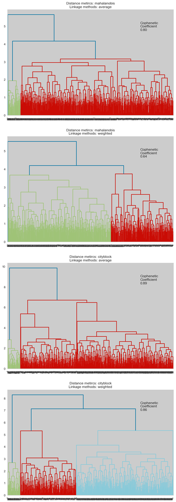

```python
# Create a subplot image
fig, axs = plt.subplots(len(distance_metrics)+len(distance_metrics), 1, figsize=(10, 30))
i=0
for dm in distance_metrics:
    for lm in linkage_methods:
        Z = linkage(subset_scaled_df, metric=dm, method=lm)
        dendrogram(Z,  ax=axs[i]);
        axs[i].set_title('Distance metircs: {}\nLinkage methods: {}'.format(dm,lm))
        coph_corr, coph_dist = cophenet(Z, pdist(subset_scaled_df))
        axs[i].annotate(f'Cophenetic\nCoefficient\n{coph_corr:0.2f}',
                        (0.80, 0.80),
                        xycoords='axes fraction')
        axs[i].set_title('Distance metircs: {}\nLinkage methods: {}'.format(dm,lm))
        i +=1
```

- 3 cluster would be appropriate number of cluster from dendrogram with ward linkage method

```python
#### generate the linkage matrix
Z = linkage(subset_scaled_df, 'ward', metric='euclidean')
Z.shape
```

```
(648, 4)
```

```python
Z[:]
```

```
array([[ 606.        ,  620.        ,    0.        ,    2.        ],
       [ 608.        ,  613.        ,    0.        ,    2.        ],
       [ 636.        ,  648.        ,    0.        ,    2.        ],
       ...,
       [1291.        , 1293.        ,   17.93479944,  379.        ],
       [1279.        , 1294.        ,   43.45779566,  429.        ],
       [1292.        , 1295.        ,   51.51230126,  649.        ]])
```

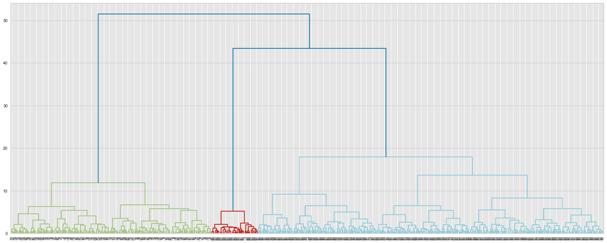

```python
plt.figure(figsize=(25, 10))
dendrogram(Z)
plt.show()
```

```python
### From the truncated dendrogram, find out the optimal distance between clusters which u want to use an input for clustering data
```

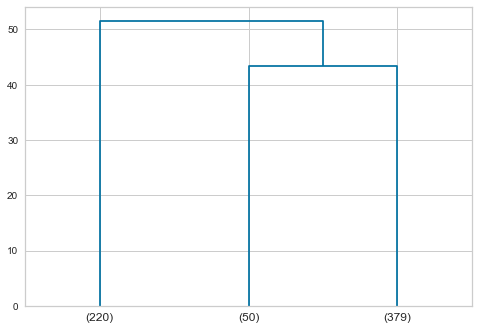

```python
# Hint: Use truncate_mode='lastp' attribute in dendrogram function to arrive at dendrogram
dendrogram(
    Z,
    truncate_mode='lastp',  # show only the last p merged clusters
    p=3,  # show only the last p merged clusters
)
plt.show()
```

```python
max_d = 44
```

```python
from scipy.cluster.hierarchy import fcluster
clusters = fcluster(Z, max_d, criterion='distance')
clusters
```

```
array([2, 1, 2, 2, 2, 1, 2, 1, 1, 1, 1, 1, 1, 1, 1, 1, 1, 1, 1, 1, 1, 1,
       1, 1, 1, 1, 1, 1, 1, 1, 1, 1, 1, 1, 1, 1, 1, 1, 1, 1, 1, 1, 1, 1,
       1, 1, 1, 1, 1, 1, 1, 1, 1, 1, 1, 1, 1, 1, 1, 1, 1, 1, 1, 1, 1, 1,
       1, 1, 1, 1, 1, 1, 1, 1, 1, 1, 1, 1, 1, 1, 1, 1, 1, 1, 1, 1, 1, 1,
       1, 1, 1, 1, 1, 1, 1, 1, 1, 1, 1, 1, 1, 1, 1, 1, 1, 1, 1, 1, 1, 1,
       1, 1, 1, 1, 1, 1, 1, 1, 1, 1, 1, 1, 1, 1, 1, 1, 1, 1, 1, 1, 1, 1,
       1, 1, 1, 1, 1, 1, 1, 1, 1, 1, 1, 1, 1, 1, 1, 1, 1, 1, 1, 1, 1, 1,
       1, 1, 1, 1, 1, 1, 1, 1, 1, 1, 1, 1, 1, 1, 1, 1, 1, 1, 1, 1, 1, 1,
       1, 1, 1, 1, 1, 1, 1, 1, 1, 1, 1, 1, 1, 1, 1, 1, 1, 1, 1, 1, 1, 1,
       1, 1, 1, 1, 1, 1, 1, 1, 1, 1, 1, 1, 1, 1, 1, 1, 1, 1, 1, 1, 1, 1,
       1, 1, 1, 1, 1, 2, 2, 2, 2, 2, 2, 2, 2, 2, 2, 2, 2, 2, 2, 2, 2, 2,
       2, 2, 2, 2, 2, 2, 2, 2, 2, 2, 2, 2, 2, 2, 2, 2, 2, 2, 2, 2, 2, 2,
       2, 2, 2, 2, 2, 2, 2, 2, 2, 2, 2, 2, 2, 2, 2, 2, 2, 2, 2, 2, 2, 2,
       2, 2, 2, 2, 2, 2, 2, 2, 2, 2, 2, 2, 2, 2, 2, 2, 2, 2, 2, 2, 2, 2,
       2, 2, 2, 2, 2, 2, 2, 2, 2, 2, 2, 2, 2, 2, 2, 2, 2, 2, 2, 2, 2, 2,
       2, 2, 2, 2, 2, 2, 2, 2, 2, 2, 2, 2, 2, 2, 2, 2, 2, 2, 2, 2, 2, 2,
       2, 2, 2, 2, 2, 2, 2, 2, 2, 2, 2, 2, 2, 2, 2, 2, 2, 2, 2, 2, 2, 2,
       2, 2, 2, 2, 2, 2, 2, 2, 2, 2, 2, 2, 2, 2, 2, 2, 2, 2, 2, 2, 2, 2,
       2, 2, 2, 2, 2, 2, 2, 2, 2, 2, 2, 2, 2, 2, 2, 2, 2, 2, 2, 2, 2, 2,
       2, 2, 2, 2, 2, 2, 2, 2, 2, 2, 2, 2, 2, 2, 2, 2, 2, 2, 2, 2, 2, 2,
       2, 2, 2, 2, 2, 2, 2, 2, 2, 2, 2, 2, 2, 2, 2, 2, 2, 2, 2, 2, 2, 2,
       2, 2, 2, 2, 2, 2, 2, 2, 2, 2, 2, 2, 2, 2, 2, 2, 2, 2, 2, 2, 2, 2,
       2, 2, 2, 2, 2, 2, 2, 2, 2, 2, 2, 2, 2, 2, 2, 2, 2, 2, 2, 2, 2, 2,
       2, 2, 2, 2, 2, 2, 2, 2, 2, 2, 2, 2, 2, 2, 2, 2, 2, 2, 2, 2, 2, 2,
       2, 2, 2, 2, 2, 2, 2, 2, 2, 2, 2, 2, 2, 2, 2, 2, 2, 2, 2, 2, 2, 2,
       2, 2, 2, 2, 2, 2, 2, 2, 2, 2, 2, 2, 2, 2, 2, 2, 2, 2, 2, 2, 2, 2,
       2, 2, 2, 2, 2, 2, 2, 2, 2, 2, 2, 2, 2, 2, 2, 2, 2, 2, 2, 2, 2, 2,
       2, 2, 2, 2, 2, 2, 2, 2, 2, 2, 2, 2, 2, 2, 2, 2, 2, 2, 2, 2, 2, 2,
       2, 2, 2, 2, 2, 2, 2, 2, 2, 2, 2, 2, 2, 2, 2, 2, 2, 2, 2, 2, 2, 2,
       2, 2, 2, 2, 2, 2, 2, 2, 2, 2, 2], dtype=int32)
```

```python
# Calculate Avg Silhoutte Score
from sklearn.metrics import silhouette_score
silhouette_score(subset_scaled_df,clusters)
```

```
0.4199617640098909
```

Silhouette Score is better when closer 1 and worse when closer to -1 here, the value is 0.42 and is better value.

### Final dendogram with 'ward linkage'

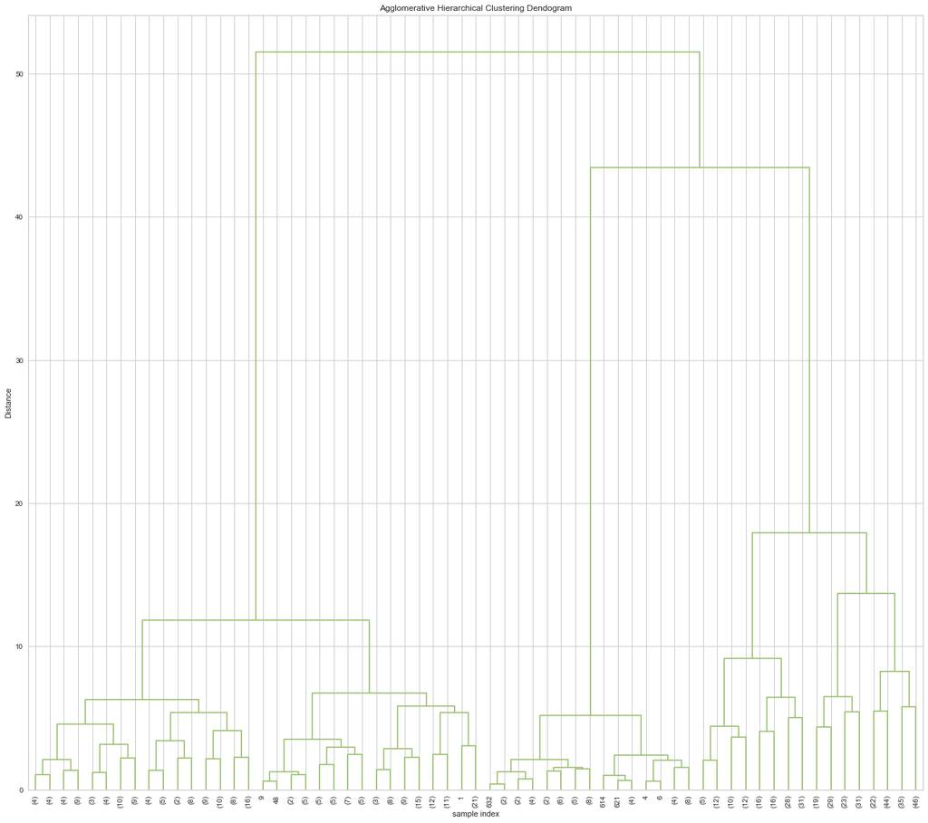

```python
from scipy.cluster.hierarchy import dendrogram, linkage
from scipy.spatial.distance import pdist
import matplotlib.pyplot as plt
plt.figure(figsize=(18, 16))
plt.title('Agglomerative Hierarchical Clustering Dendogram')
plt.xlabel('sample index')
plt.ylabel('Distance')
Z = linkage(subset_scaled_df, 'ward')
dendrogram(Z,leaf_rotation=90.0,p=5,color_threshold=52,leaf_font_size=10,truncate_mode='level')
plt.tight_layout()
```

## Let us create 3 clusters

```python
#Trying with K value as 3
HCmodel = AgglomerativeClustering(n_clusters=3,affinity='euclidean', linkage='ward')
HCmodel.fit(subset_scaled_df)
subset_scaled_df['HC_Clusters'] = HCmodel.labels_
```

```python
CC1_df['HC_Clusters'] = HCmodel.labels_
```

```python
cluster_profile1 = CC1_df.groupby('HC_Clusters').mean()
```

```python
cluster_profile1['count_in_each_segments'] = CC1_df.groupby('HC_Clusters')['Total_calls_made'].count().values
```

```python
# lets display cluster profile
cluster_profile1.style.highlight_max(color = 'orange', axis = 0)
```

| HC_Clusters | Avg_Credit_Limit | Total_Credit_Cards | Total_visits_bank | Total_visits_online | Total_calls_made | count_in_each_segments |
| --- | --- | --- | --- | --- | --- | --- |
| 0 | 34000.000000 | 5.514512 | 3.480211 | 0.984169 | 1.997361 | 379 |
| 1 | 12263.636364 | 2.404545 | 0.940909 | 3.561364 | 6.904545 | 220 |
| 2 | 103440.000000 | 8.740000 | 0.600000 | 8.180000 | 1.080000 | 50 |

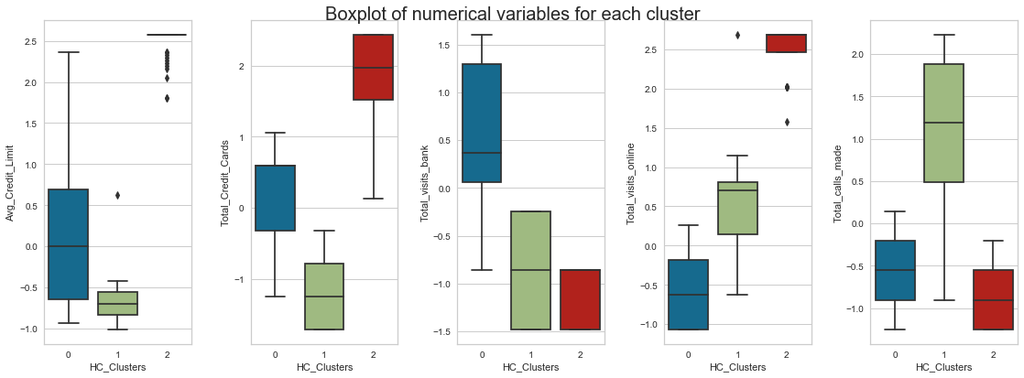

```python
fig, axes = plt.subplots(1, 5,  figsize=(16, 6))
fig.suptitle('Boxplot of numerical variables for each cluster', fontsize=20)
counter = 0
for ii in range(5):
    sns.boxplot(ax=axes[ii],y=subset_scaled_df[all_col[counter]],x=subset_scaled_df['HC_Clusters'])
    counter = counter+1

fig.tight_layout(pad=2.0)
```

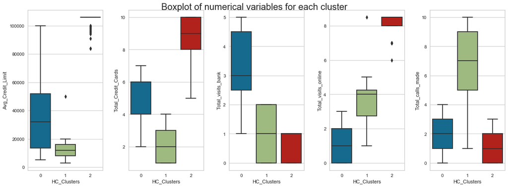

```python
fig, axes = plt.subplots(1, 5,  figsize=(16, 6))
fig.suptitle('Boxplot of numerical variables for each cluster', fontsize=20)
counter = 0
for ii in range(5):
    sns.boxplot(ax=axes[ii],y=CC1_df[all_col[counter]],x=CC1_df['HC_Clusters'])
    counter = counter+1

fig.tight_layout(pad=2.0)
```

**Lets compare Cluster**

```python
pd.crosstab(CC1_df['HC_Clusters'], CC1_df.Total_visits_bank).style.highlight_max(color = 'lightblue', axis = 0)
```

| Total_visits_bank HC_Clusters | 0 | 1 | 2 | 3 | 4 | 5 |
| --- | --- | --- | --- | --- | --- | --- |
| 0 | 0 | 3 | 92 | 99 | 90 | 95 |
| 1 | 77 | 79 | 64 | 0 | 0 | 0 |
| 2 | 20 | 30 | 0 | 0 | 0 | 0 |

```python
pd.crosstab(CC1_df['HC_Clusters'], CC1_df.Total_visits_online).style.highlight_max(color = 'lightblue', axis = 0)
```

| Total_visits_online HC_Clusters | 0.0 | 1.0 | 2.0 | 3.0 | 4.0 | 5.0 | 6.0 | 7.0 | 8.0 | 8.5 |
| --- | --- | --- | --- | --- | --- | --- | --- | --- | --- | --- |
| 0 | 141 | 104 | 133 | 1 | 0 | 0 | 0 | 0 | 0 | 0 |
| 1 | 0 | 3 | 52 | 42 | 68 | 54 | 0 | 0 | 0 | 1 |
| 2 | 0 | 0 | 0 | 0 | 0 | 0 | 1 | 7 | 6 | 36 |

```python
pd.crosstab(CC1_df['HC_Clusters'], CC1_df.Total_calls_made).style.highlight_max(color = 'lightblue', axis = 0)
```

| Total_calls_made HC_Clusters | 0 | 1 | 2 | 3 | 4 | 5 | 6 | 7 | 8 | 9 | 10 |
| --- | --- | --- | --- | --- | --- | --- | --- | --- | --- | --- | --- |
| 0 | 80 | 72 | 71 | 81 | 75 | 0 | 0 | 0 | 0 | 0 | 0 |
| 1 | 0 | 1 | 1 | 0 | 29 | 28 | 39 | 34 | 30 | 32 | 26 |
| 2 | 16 | 15 | 18 | 1 | 0 | 0 | 0 | 0 | 0 | 0 | 0 |

```python
pd.crosstab(CC1_df['HC_Clusters'], CC1_df.Total_Credit_Cards).style.highlight_max(color = 'lightblue', axis = 0)
```

| Total_Credit_Cards HC_Clusters | 1 | 2 | 3 | 4 | 5 | 6 | 7 | 8 | 9 | 10 |
| --- | --- | --- | --- | --- | --- | --- | --- | --- | --- | --- |
| 0 | 0 | 1 | 0 | 100 | 73 | 112 | 93 | 0 | 0 | 0 |
| 1 | 58 | 62 | 53 | 47 | 0 | 0 | 0 | 0 | 0 | 0 |
| 2 | 0 | 0 | 0 | 0 | 1 | 1 | 7 | 11 | 11 | 19 |

# 6. Compare cluster K-means clusters and Hierarchical clusters - Perform cluster profiling - Derive Insights

*K-means clusters*

```python
# lets display cluster profile
cluster_profile.style.highlight_max(color = 'lightgreen', axis = 0)
```

| K_means_segments | Avg_Credit_Limit | Total_Credit_Cards | Total_visits_bank | Total_visits_online | Total_calls_made | count_in_each_segment |
| --- | --- | --- | --- | --- | --- | --- |
| 0 | 12239.819005 | 2.411765 | 0.945701 | 3.554299 | 6.891403 | 221 |
| 1 | 34071.428571 | 5.518519 | 3.484127 | 0.981481 | 1.992063 | 378 |
| 2 | 103440.000000 | 8.740000 | 0.600000 | 8.180000 | 1.080000 | 50 |

### Insights

- **Cluster 0**:
  - The cluster 0 contains the customers who has made higher number of calls than median.
  - The cluster 0 contains the customers whose Avg.credit limit is less than median value.
  - The cluster 0 contains the customers whose total credit cards are less than median value.
  - The cluster 0 contains the customers whose total visits to banks is very less than median value.
  - The cluster 0 contains the customers whose total visits online is more than median value.
- **Cluster 1**:
  - The cluster 1 contains the customers who has made less calls than median value.
  - The cluster 1 contains the customers whose Avg.credit limit is more than median value.
  - The cluster 1 contains the customers whose total credit cards are more than median value.
  - The cluster 1 contains the customers whose total visits to banks is very much higher than median value.
  - The cluster 1 contains the customers whose total visits online is less than median value.
- **Cluster 2**:
  - The cluster 2 contains the customers who has made less calls than median.
  - The cluster 2 contains the customers whose Avg.credit limit is very much higher than median value.
  - The cluster 2 contains the customers whose total credit cards is very much higher than median value.
  - The cluster 2 contains the customers whose total visits to banks is very less than median value.
  - The cluster 2 contains the customers whose total visits online is very much higher than median value.

*Hierarchical clusters*

```python
# lets display cluster profile
cluster_profile1.style.highlight_max(color = 'orange', axis = 0)
```

| HC_Clusters | Avg_Credit_Limit | Total_Credit_Cards | Total_visits_bank | Total_visits_online | Total_calls_made | count_in_each_segments |
| --- | --- | --- | --- | --- | --- | --- |
| 0 | 34000.000000 | 5.514512 | 3.480211 | 0.984169 | 1.997361 | 379 |
| 1 | 12263.636364 | 2.404545 | 0.940909 | 3.561364 | 6.904545 | 220 |
| 2 | 103440.000000 | 8.740000 | 0.600000 | 8.180000 | 1.080000 | 50 |

### Insights

- **Cluster 0**:
  - The cluster 0 contains the customers who has made less calls than median value.
  - The cluster 0 contains the customers whose Avg.credit limit is more than median value.
  - The cluster 0 contains the customers whose total credit cards are more than median value.
  - The cluster 0 contains the customers whose total visits to banks is very much higher than median value.
  - The cluster 0 contains the customers whose total visits online is less than median value.
- **Cluster 1**:
  - The cluster 1 contains the customers who has made higher number of calls than median.
  - The cluster 1 contains the customers whose Avg.credit limit is less than median value.
  - The cluster 1 contains the customers whose total credit cards are less than median value.
  - The cluster 1 contains the customers whose total visits to banks is very less than median value.
  - The cluster 1 contains the customers whose total visits online is more than median value.
- **Cluster 2**:
  - The cluster 2 contains the customers who has made less calls than median.
  - The cluster 2 contains the customers whose Avg.credit limit is very much higher than median value.
  - The cluster 2 contains the customers whose total credit cards is very much higher than median value.
  - The cluster 2 contains the customers whose total visits to banks is very less than median value.
  - The cluster 2 contains the customers whose total visits online is very much higher than median value.

**The K-means clusters and Hierarchical clusters has derived same number of clusters and has given almost same cluster patterns**

# 7. Actionable Insights & Recommendations

### Business Insights and Recommendations recommendation

- **Cluster 0: 58% of the total customers.** The Customer profile has good Avg.credit limit,good number of credit cards and total visits bank is very much higher. These customers makes less online visits and makes very less calls.
  - **Recommendation - Banks can consider this customer profile as moderate income profile with good credit limits,good number of cards and visits bank frequently for any transactions and queries**
  - Banks can target these customers to apply for better Credit limits, apply credit cards.
  - Banks can target to meet such customers in person in bank to sell some products like insurance, policy.etc..
  - Banks can encourage them to use online facility and customer care instead of visiting banks for small queries or transactions
- **Cluster 1: 34% of the total customers.** The customer profile makes more number of calls and has very less credit limits,less cards,less visits to bank and a better online visits.
  - **Recommendation - Banks can consider this customer profile as less income profile with less credit limits,less cards and doesn't visit to banks frequently.**
  - Banks can check the quality of calls made by this customers and encourage them to use more online to solve instead of making calls.
  - Banks can try to sell any policy, insurance,etc..during the calls.
- **Cluster 2: 8% of the total customers.** The customer profile has very high credit limits, more cards and visits online very frequently. They make very less calls and less visits to bank.
  - **Recommendation - Banks can consider this customer profile as high income profile with high credit limits,having more cards and uses internet online very frequently. They don't make calls or visits to bank for any transaction or queries very frequently.**
  - Banks can target these customers for increasing credit limits, apply cards and online coupons for purchasing any products from bank.
  - Banks can give some discounts or waive annual fees for credit cards since they are valuable customers.